# 2.9 Practical: nonlinear model - population dynamics

Benjamin Rosenbaum

October 20, 2020

# Model

In this exercise, we move to a nonlinear model in population dynamics.

The deterministic model may look complicated, but the statistics are the same as before.

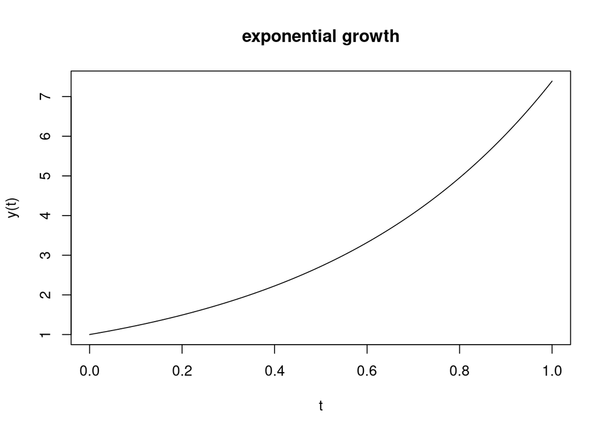

```r
curve(1*exp(2*x), xlab="t", ylab="y(t)", main="exponential growth")
```

Exponential growth of a population density $y(t)$ over time $t$ is described by a differential equation
$$\frac{dy(t)}{dt} = r\cdot y(t)$$
with an initial density $y(t_0)=y_0$ in $t_0=0$ and a growth rate $r$.

There is an explicit formulation that describes the population density at time $t$:
$$y(\color{red}{t})=y_0\cdot\exp(r\cdot \color{red}{t})$$

This model is unrealistic in the sense that it grows exponentially to infinity over time.

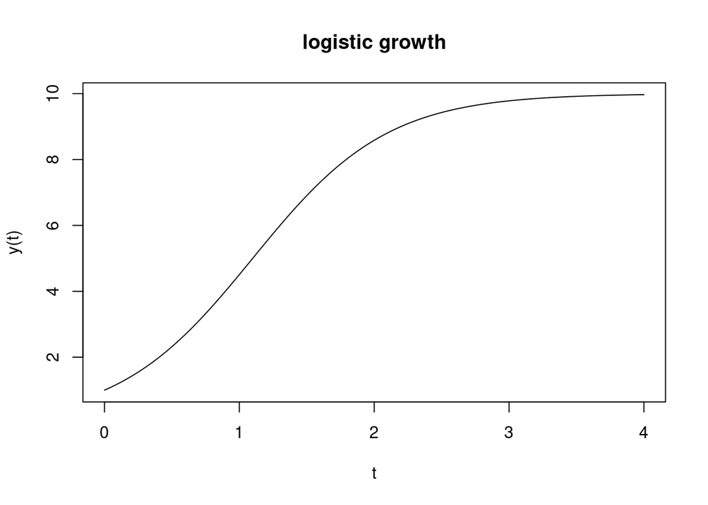

```r
curve(10/( 1+(10-1)/1 * exp(-2*x) ) , from=0, to=4, xlab="t", ylab="y(t)", main="logistic growth")
```

A more realistic model is logistic growth, where the population densitiy grows only it reaches a carrying capacity $K$.
$$\frac{dy(t)}{dt}= r\cdot(1-\frac{y(t)}{K})\cdot y(t),$$

with an initial density $y(t_0)=y_0$ in $t_0=0$.

If carrying capacity is reached ($y(t)=K$), the term in parentheses and therefore the whole expression is zero and the population size reaches an equilibrium.

For this differential equation, there also is an explicit formulation describing population size $y(t)$ at time $t$:
$$y(\color{red}{t}) = \frac{K}{ 1+ \frac{K-y_0}{y_0} \cdot \exp(-r\cdot \color{red}{t}) }$$
This looks complicated, but for any given $y_0,K,r$ we can directly compute $y(t)$.

Given some time series data $t_i, y_i$ ($i=1,...,n$), we formulate a statistical model:
$$\begin{align}
\mu_i & = \frac{K}{ 1+ \frac{K-y_0}{y_0} \cdot \exp(-r\cdot t_i) } \\
y_i & \sim \text{normal}(\mu_i, \sigma)
\end{align}$$

The parameters are $y_0, r, K$.

Why is $y_0$ a parameter? There is measurement for that (observation in $t_0$).

Yes, and that measurement is assumed to have an observation error $\sigma$ just like all observations!

Have a look at the equation, $y_0$ has an influence on all $y(t)$, so leaving it as a free parameter leaves more freedom to the model. Just think of it as an intercept in $t_0$!

There are more sophisticated ways to model time series data, but for now let’s just fit this nonlinear equation $y(t)$ with a predictor $t$.

# Setup

```r
rm(list=ls())
library(rstan)
library(coda)
```

```r
library(BayesianTools)
setwd("~/Nextcloud/teaching Bayes")

rstan_options(auto_write = TRUE)
options(mc.cores = 3)
```

# Generate data

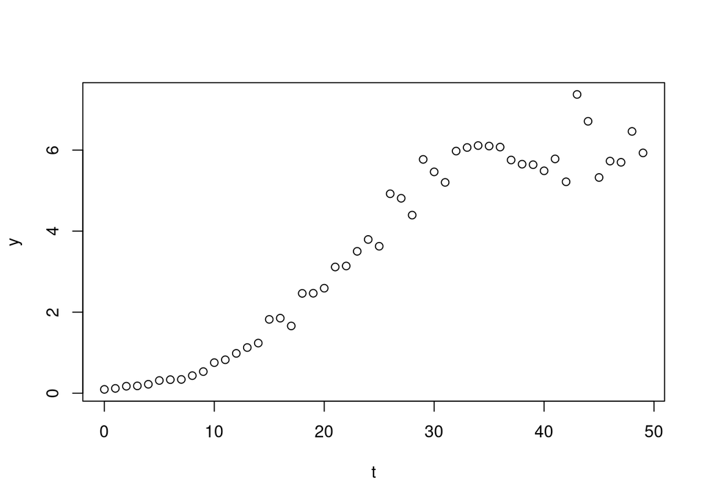

```r
set.seed(123) # initiate random number generator for reproducibility

n = 50
t = 0:(n-1)

r = 0.2
K = 6
y0 = 0.1

y = K/( 1+(K-y0)/y0 * exp(-r*t) )

y = exp(rnorm(n,mean=log(y),sd=0.1))

plot(t,y)
```

```r
data = list(n=n,
            y=y,
            t=t)
```

# Stan code and fitting

```r
stan_code = '
data {
  int n;
  real y[n];
  real t[n];
}
parameters {
  real<lower=0> y0;
  real<lower=0> r;
  real<lower=0> K;
  real<lower=0> sigma;
}
model {
  // priors
  y0 ~ normal(0, 10);
  r ~ normal(0, 10);
  K ~ normal(0, 10);
  sigma ~ normal(0,10);

  // likelihood
  for (i in 1:n){
    y[i] ~ normal( K/( 1+(K-y0)/y0 * exp(-r*t[i]) ), sigma );
  }
}
'

stan_model = stan_model(model_code=stan_code)
# save(stan_model, file="stan_model.RData")
# load("stan_model.RData")

fit  = sampling(stan_model,
                data=data,
                chains=3,
                iter=2000,
                warmup=1000
)
```

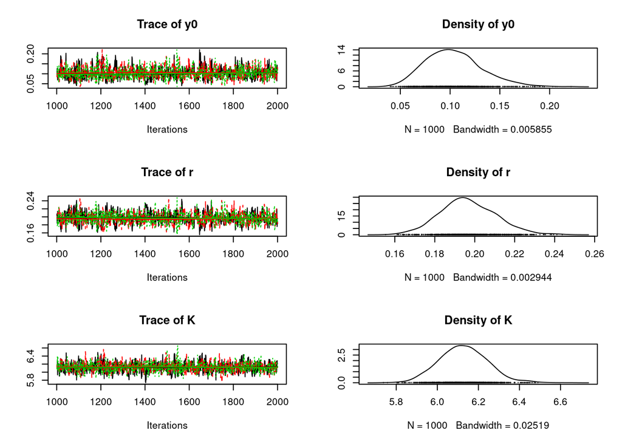

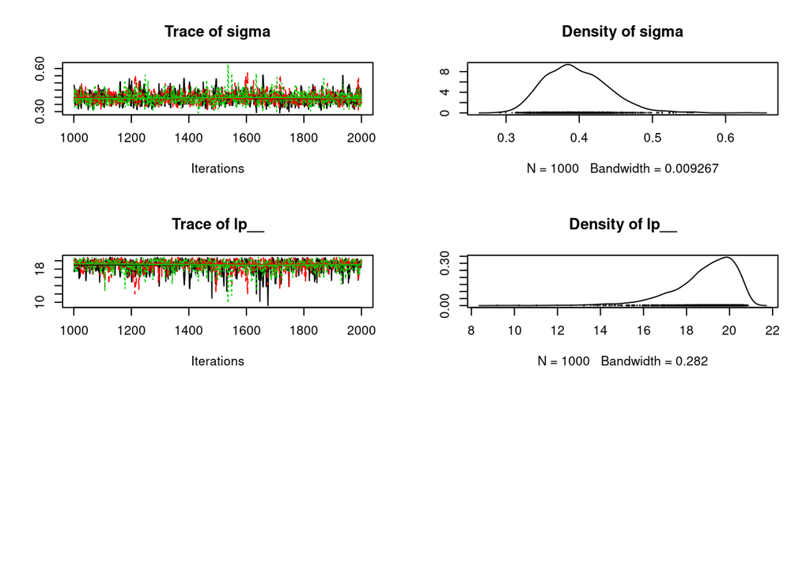

```r
print(fit, digits=3, probs=c(0.025, 0.975))

# plot(fit)
plot(As.mcmc.list(fit)) # from coda package
```

[output not shown]

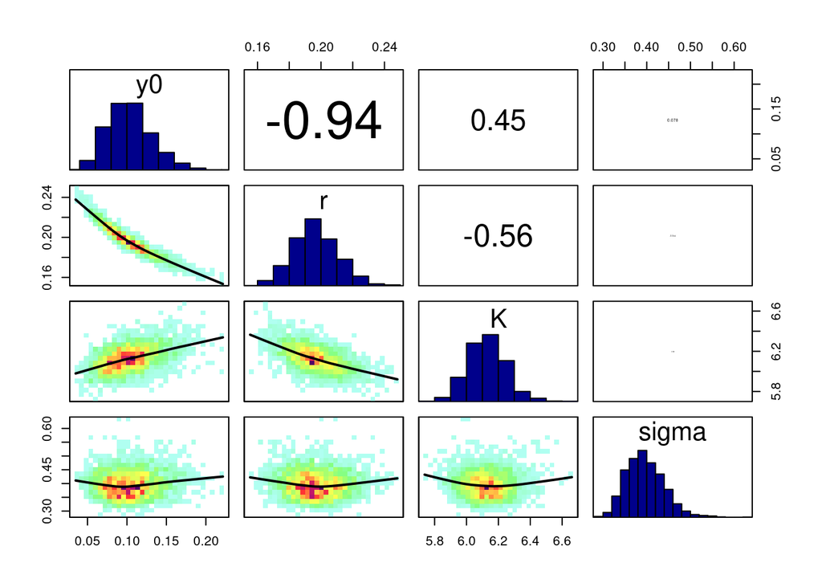

```r
posterior=as.matrix(fit)

correlationPlot(posterior[,1:4], thin=1)
```

# Predictions

We generate credible / confidence intervals for the deterministic model and prediction intervals for the whole model.

Again, you could also code the directly in the model using the `generated quantitites{}` block.

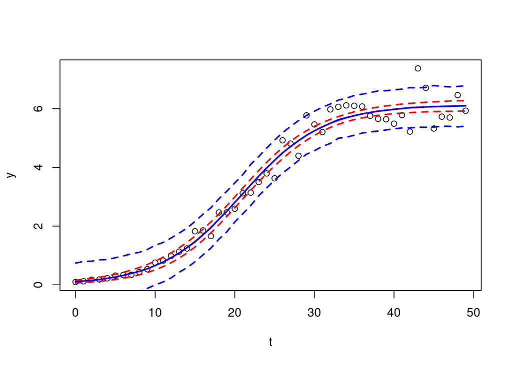

```r
t.pred = data$t
y.cred = matrix(0, nrow=nrow(posterior), ncol=length(t.pred))

for(i in 1:nrow(posterior)){
  y.cred[i, ] = posterior[i,"K"]/( 1+(posterior[i,"K"]-posterior[i,"y0"])/posterior[i,"y0"] * exp(-posterior[i,"r"]*t.pred) )
}

plot(t,y)

y.cred.mean = apply(y.cred, 2, function(x) mean(x))
lines(t.pred, y.cred.mean, col="red", lwd=2)

y.cred.q05 = apply(y.cred, 2, function(x) quantile(x, probs=0.05))
lines(t.pred, y.cred.q05, col="red", lwd=2, lty=2)

y.cred.q95 = apply(y.cred, 2, function(x) quantile(x, probs=0.95))
lines(t.pred, y.cred.q95, col="red", lwd=2, lty=2)

y.pred = matrix(0, nrow=nrow(posterior), ncol=length(t.pred))
for(i in 1:nrow(posterior)){
  y.pred[i, ] = rnorm(n=length(t.pred),
                     mean = posterior[i,"K"]/( 1+(posterior[i,"K"]-posterior[i,"y0"])/posterior[i,"y0"] * exp(-posterior[i,"r"]*t.pred) ),
                     sd = posterior[i,"sigma"])
}

y.pred.mean = apply(y.pred, 2, function(x) mean(x))
lines(t.pred, y.pred.mean, col="blue", lwd=2)

y.pred.q05 = apply(y.pred, 2, function(x) quantile(x, probs=0.05))
lines(t.pred, y.pred.q05, col="blue", lwd=2, lty=2)

y.pred.q95 = apply(y.pred, 2, function(x) quantile(x, probs=0.95))
lines(t.pred, y.pred.q95, col="blue", lwd=2, lty=2)
```

The model predicts values < 0. For populations, this doesn’t make any sense.

Let’s look closer at observed vs. predicted.

Here, `t.pred` are the same predictor values as in the data, so we can make the observed-predicted plot directly.

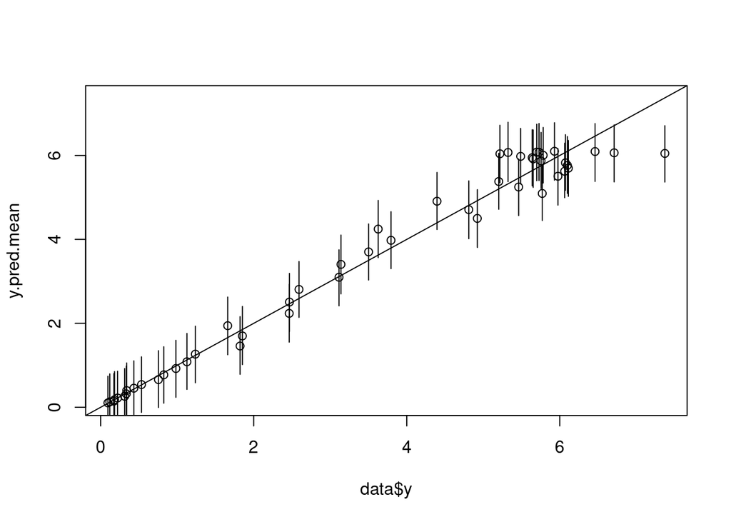

```r
plot(data$y, y.pred.mean, ylim=c(min(data$y), max(data$y)))
abline(0,1)
for (i in 1:n){
  lines(c(data$y[i], data$y[i]), c(y.pred.q05[i], y.pred.q95[i]))
}
```

stochastic model: $y_i\sim\text{normal}(\mu_i,\sigma)$.

Even if the deterministic model ensures $\mu_i>0$, the statistical model (normal distribution) allows negative predictions, while it should be bounded at zero.

Also, the variation in the data seems to grow with $y$ (“heteroscedasticity”).

# Lognormal residuals model

Next, we will try a more appropriate stochastic model (lognormal distribution).

$y\sim\text{lognormal}(\mu,\sigma)$ is the same as $\log(y)\sim\text{normal}(\mu,\sigma)$.

$\mu,\sigma$ are now mean and standard deviation of $\log(y)$.

```r
stan_code_lognormal = '
data {
  int n;
  real y[n];
  real t[n];
}
parameters {
  real<lower=0> y0;
  real<lower=0> r;
  real<lower=0> K;
  real<lower=0> sigma;
}
model {
  // priors
  y0 ~ normal(0, 10);
  r ~ normal(0, 10);
  K ~ normal(0, 10);
  sigma ~ normal(0,10);

  // likelihood
  for (i in 1:n){
    y[i] ~ lognormal( log( K/( 1+(K-y0)/y0 * exp(-r*t[i]) ) ), sigma );
  }
}
'

stan_model_lognormal = stan_model(model_code=stan_code_lognormal)
# save(stan_model_lognormal, file="stan_model_lognormal.RData")
# load("stan_model_lognormal.RData")

fit_lognormal  = sampling(stan_model_lognormal,
                          data=data,
                          chains=3,
                          iter=2000,
                          warmup=1000
)
```

```r
print(fit_lognormal, digits=3, probs=c(0.025, 0.975))
```

```
## Inference for Stan model: 30fdaf46d6028d32c28c09cbe8b97ecc.
## 3 chains, each with iter=2000; warmup=1000; thin=1;
## post-warmup draws per chain=1000, total post-warmup draws=3000.
##
##         mean se_mean    sd   2.5%  97.5% n_eff  Rhat
## y0     0.105   0.000 0.004  0.096  0.114  1456 1.000
## r      0.195   0.000 0.004  0.187  0.204  1250 1.000
## K      6.082   0.003 0.140  5.811  6.355  1697 1.000
## sigma  0.096   0.000 0.010  0.079  0.118  1896 0.999
## lp__  88.539   0.043 1.444 84.837 90.333  1121 1.001
##
## Samples were drawn using NUTS(diag_e) at Wed Oct 14 10:52:28 2020.
## For each parameter, n_eff is a crude measure of effective sample size,
## and Rhat is the potential scale reduction factor on split chains (at
## convergence, Rhat=1).
```

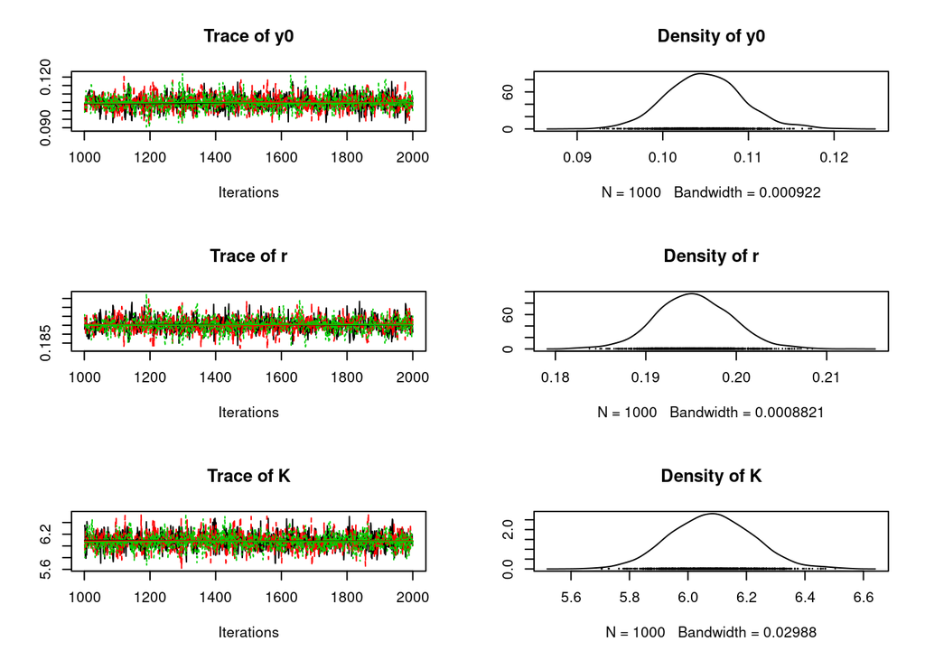

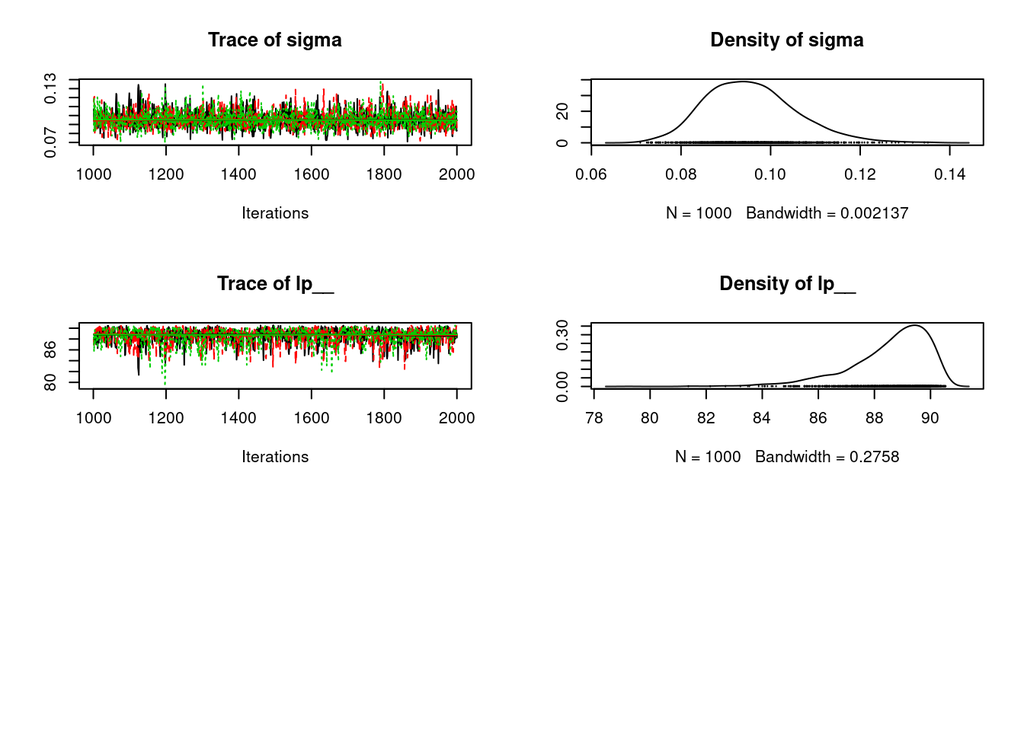

```r
# plot(fit_lognormal)
plot(As.mcmc.list(fit_lognormal)) # from coda package
```

```r
posterior=as.matrix(fit_lognormal)
```

# Predictions

Again, credible / confidence intervals for the deterministic model and prediction intervals for the whole model.

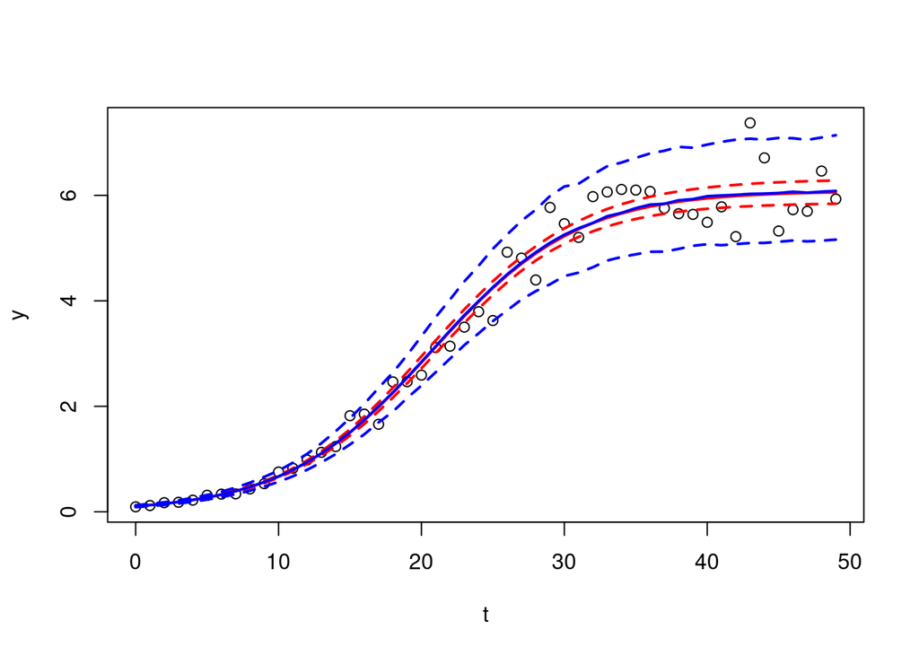

```r
t.pred = data$t
y.cred = matrix(0, nrow=nrow(posterior), ncol=length(t.pred))

for(i in 1:nrow(posterior)){
  y.cred[i, ] = posterior[i,"K"]/( 1+(posterior[i,"K"]-posterior[i,"y0"])/posterior[i,"y0"] * exp(-posterior[i,"r"]*t.pred) )
}

plot(t,y)

y.cred.mean = apply(y.cred, 2, function(x) mean(x))
lines(t.pred, y.cred.mean, col="red", lwd=2)

y.cred.q05 = apply(y.cred, 2, function(x) quantile(x, probs=0.05))
lines(t.pred, y.cred.q05, col="red", lwd=2, lty=2)

y.cred.q95 = apply(y.cred, 2, function(x) quantile(x, probs=0.95))
lines(t.pred, y.cred.q95, col="red", lwd=2, lty=2)

y.pred = matrix(0, nrow=nrow(posterior), ncol=length(t.pred))
for(i in 1:nrow(posterior)){
  y.pred[i, ] = rlnorm(n=length(t.pred),
                      meanlog = log( posterior[i,"K"]/( 1+(posterior[i,"K"]-posterior[i,"y0"])/posterior[i,"y0"] * exp(-posterior[i,"r"]*t.pred) ) ),
                      sdlog = posterior[i,"sigma"])
}

y.pred.mean = apply(y.pred, 2, function(x) mean(x))
lines(t.pred, y.pred.mean, col="blue", lwd=2)

y.pred.q05 = apply(y.pred, 2, function(x) quantile(x, probs=0.05))
lines(t.pred, y.pred.q05, col="blue", lwd=2, lty=2)

y.pred.q95 = apply(y.pred, 2, function(x) quantile(x, probs=0.95))
lines(t.pred, y.pred.q95, col="blue", lwd=2, lty=2)
```

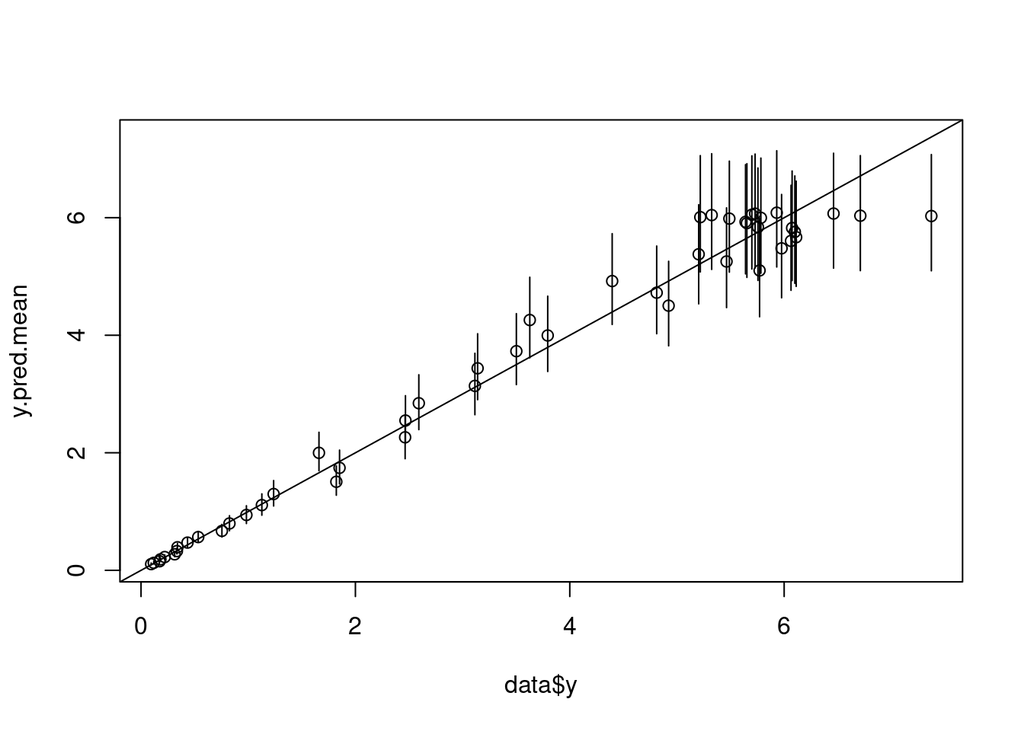

```r
plot(data$y, y.pred.mean, ylim=c(min(data$y), max(data$y)))
abline(0,1)
for (i in 1:n){
  lines(c(data$y[i], data$y[i]), c(y.pred.q05[i], y.pred.q95[i]))
}
```

Model predictions look much better than before.

The variation in the predicted values grows with $y$, just as in the observed data.

On the logscale, variation is constant:

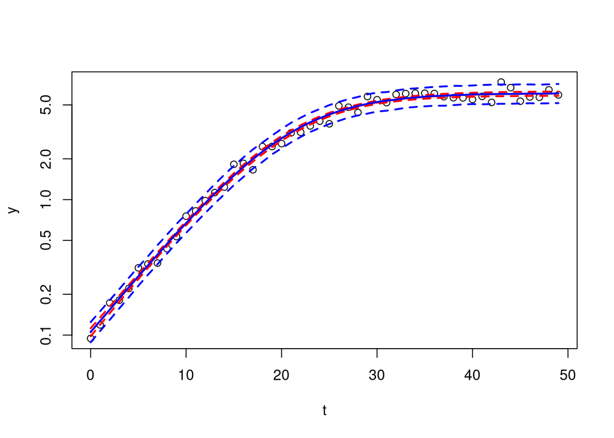

```r
plot(t,y, log="y")
lines(t.pred, y.cred.mean, col="red", lwd=2)
lines(t.pred, y.cred.q05, col="red", lwd=2, lty=2)
lines(t.pred, y.cred.q95, col="red", lwd=2, lty=2)

lines(t.pred, y.pred.mean, col="blue", lwd=2)
lines(t.pred, y.pred.q05, col="blue", lwd=2, lty=2)
lines(t.pred, y.pred.q95, col="blue", lwd=2, lty=2)
```

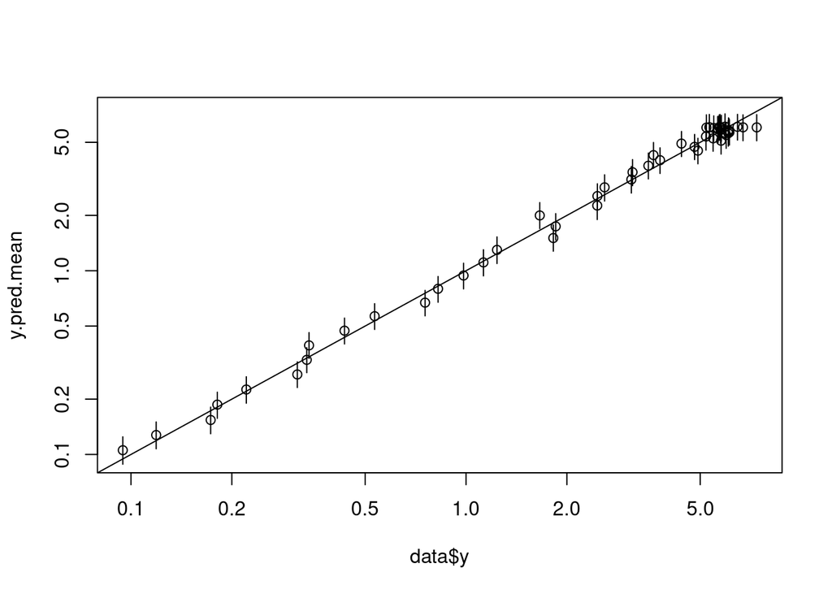

```r
plot(data$y, y.pred.mean, ylim=c(min(data$y), max(data$y)), log="xy")
abline(0,1)
for (i in 1:n){
  lines(c(data$y[i], data$y[i]), c(y.pred.q05[i], y.pred.q95[i]))
}
```